# Raport z eksperymentu

Mateusz Bujnowski

2025-05-17

# Wstęp

## Zadanie

Należy przygotować eksperyment, sprawdzający czy określone problemy z czytaniem danych wciąż występują (problemy takie jak: iluzje na wykresach, błędy w odczytywaniu wykresu kołowego, błędy w pokazywaniu danych za pomocą wykresów 3D, problemy z tytułami na wykresie). Następnie należy przetestować na przynajmniej 15 innych osobach czy dany problem występuje, np. przeprowadzając ankietę.

## Cel

Celem pracy jest sprawdzenie czy “dobre praktyki” opracowane lata temu (słupki lepsze niż kąty, kolor wykorzystywany z umiarem, unikanie ozdobników), faktycznie działa w społeczeństwie, które wykresami karmione jest od urodzenia.

# Eksperyment

## Opis eksperymentu

Eksperyment polegał na sprawdzeniu wśród odbiorców, który wykres jest prostszy do odczytania - wykres kołowy czy wykres słupkowy. W tym celu przygotowano wykresy przedstawiające te same dane w dwóch różnych formach. Uczestnicy eksperymentu zostali poproszeni o ocenę, który wykres jest bardziej czytelny i łatwiejszy do zrozumienia. Poprzedzały to pytania dotyczące odczytu poszczególnych informacji z wykresu kołowego. Dotyczyły one tych samych danych przedstawionbych na wykresie kołowym z uwzględnieniem kolorów, bez informacji o udziale procentowym każdego z przedziałów, oraz na wykresie słupkowym w dwóch kolorzach.

## Eksperyment - wykresy

Dane do stworzenia wykresów pochodziły z wbudowanego zbioru danych `Titanic`. Wykresy przedstawiają liczbę dorosłych na pokładzie statku Titanic, którzy przeżyli, podzieloną na płeć i klasę.

### Wykres kołowy

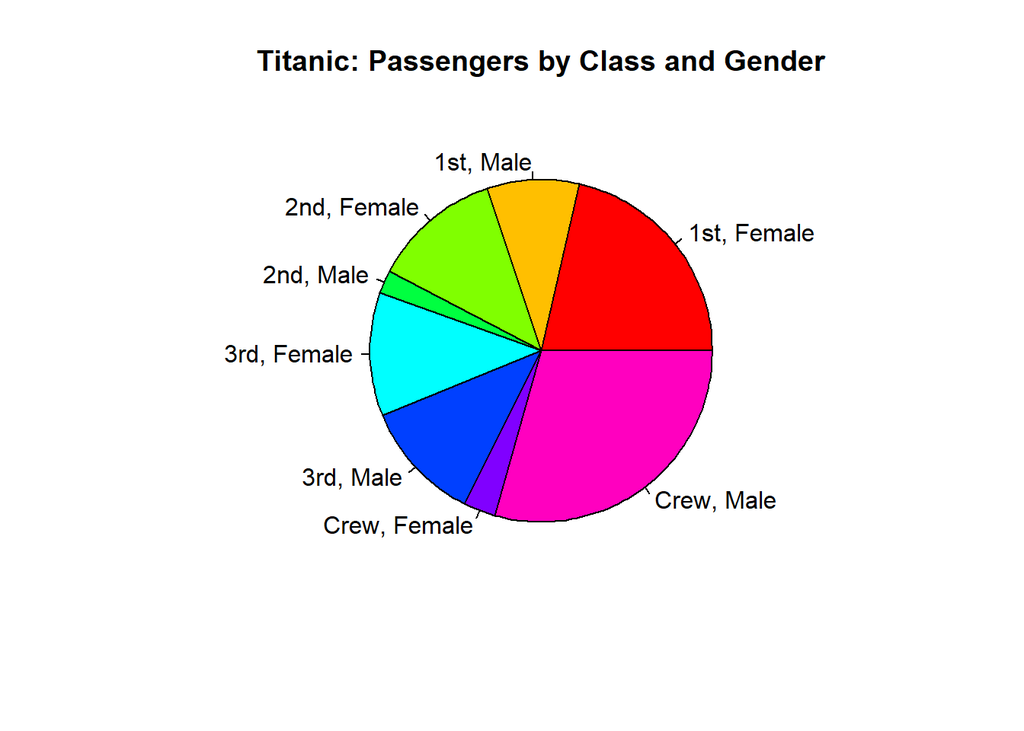

```r
# Wykres kołowy
dane <- as.data.frame(Titanic)
dane <- dane[25:32, ] %>% select(- c(Age, Survived))
label <- paste(dane$Class, dane$Sex, sep = ", ")
dane1 <-  aggregate(Freq ~ label, data = dane, sum)
pie(
  dane1$Freq,
  labels = dane1$label,
  main = "Titanic: Passengers by Class and Gender",
  col = rainbow(length(dane1$Freq))
)
```

Pokazuje poprawność odpowiedzi w ankiecie.

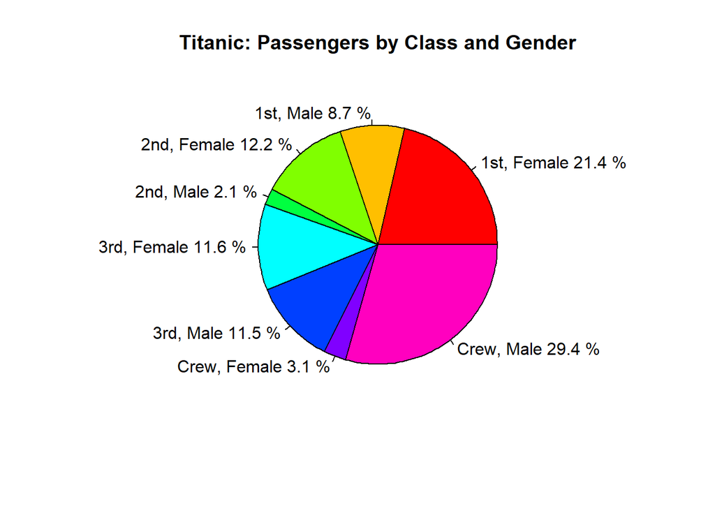

```r
# Wykres kołowy z procentami
dane <- as.data.frame(Titanic)
dane <- dane[25:32, ] %>% select(- c(Age, Survived))
label <- paste(dane$Class, dane$Sex, sep = ", ")
dane1 <-  aggregate(Freq ~ label, data = dane, sum)
pct <- round(100 * dane1$Freq / sum(dane1$Freq), 1)
labels_pct <- paste(dane1$label, pct, "%")
pie(
  dane1$Freq,
  labels = labels_pct,
  main = "Titanic: Passengers by Class and Gender",
  col = rainbow(length(dane1$Freq))
)
```

### Wykres słupkowy

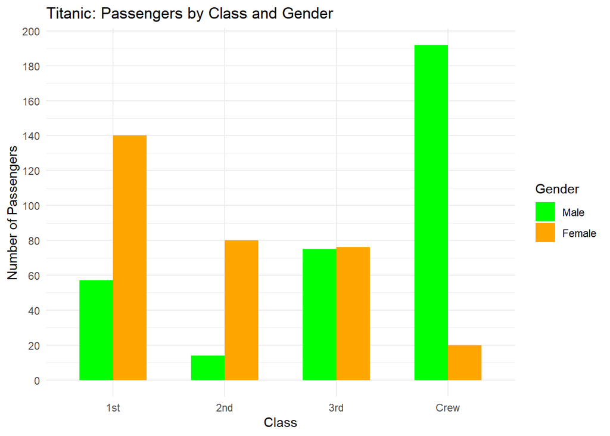

```r
# Wykres słupkowy
dane <- as.data.frame(Titanic) %>%
  slice(25:32) %>%
  select(-c(Age, Survived)) %>%
  group_by(Class, Sex) %>%
  summarise(Freq = sum(Freq), .groups = "drop")
ggplot(dane, aes(x = Class, y = Freq, fill = Sex)) +
  geom_col(position = position_dodge(width = 0.6), width = 0.6) +
  labs(
    title = "Titanic: Passengers by Class and Gender",
    x = "Class",
    y = "Number of Passengers",
    fill = "Gender"
  ) +
  theme_minimal() +
  scale_fill_manual(values = c("green", "orange")) +
  scale_y_continuous(expand = expansion(mult = 0.05),
                     breaks = seq(0, 220, by = 20))
```

## Wyniki

W przeprowadzonym badaniu wykres słupkowy był w dwóch kolorach, co pozwoliło na odczytanie wykresu również dla osób z zaburzeniami widzenia kolorów. Respondenci jednoznacznie stwierdzili, że wykres słupkowy jest bardziej czytelny i łatwiejszy do zrozumienia niż wykres kołowy. Z pośród 18 osób, w pytaniach z 4 ospowiedziami poprawnie odpowiedziała mniej niż połowa, dla pytań Tak/Nie było to mniej więcej 10 osób. Aż 17 na 18 badanych osó potwierdziło, że prostszy jest odczyt wykresu słupkowego. Wskazywali również, że wykres kołowy wprowadzał ich w błąd i był trudny do zrozumienia. Dodatkowym utrudnieniem była duża liczba przedziałów, mimo tego, że zbliżonych wielkością do siebie podziałów było tylko kilka.

### Tabelka z udzielonymi odpowiedziami

```r
tabelka <- read_xlsx('Wyniki ankiety.xlsx')
print(tabelka, row.names = F)
```

```
## # A tibble: 20 × 7
##    Odpowiedzi        `Pytanie 1` `Pytanie 2` `Pytanie 3` `Pytanie 4` `Pytanie 5`
##    <chr>             <chr>       <chr>       <chr>       <chr>       <chr>
##  1 1                 Tak         Tak         2nd, Female 26% – 28%   Tak
##  2 2                 Nie         Nie         3rd, Male   24% – 26%   Nie
##  3 3                 Tak         Nie         3rd, Female 30% – 32%   Tak
##  4 4                 Nie         Tak         1st, Male   26% – 28%   Tak
##  5 5                 Tak         Tak         3rd, Male   30% – 32%   Nie
##  6 6                 Nie         Nie         2nd, Female 24% – 26%   Nie
##  7 7                 Tak         Nie         3rd, Female 28% – 30%   Tak
##  8 8                 Nie         Tak         3rd, Male   26% – 28%   Tak
##  9 9                 Tak         Tak         2nd, Female 30% – 32%   Nie
## 10 10                Nie         Nie         3rd, Female 24% – 26%   Tak
## 11 11                Tak         Nie         2nd, Female 28% – 30%   Nie
## 12 12                Nie         Tak         1st, Male   30% – 32%   Tak
## 13 13                Tak         Tak         3rd, Male   26% – 28%   Tak
## 14 14                Nie         Nie         3rd, Female 24% – 26%   Nie
## 15 15                Tak         Nie         2nd, Female 26% – 28%   Tak
## 16 16                Nie         Tak         3rd, Male   30% – 32%   Tak
## 17 17                Nie         Nie         2nd, Female 28% – 30%   Tak
## 18 18                Nie         Nie         2nd, Female 30% – 32%   Nie
## 19 Poprawna odpowie… Nie         Nie         2nd, Female 28% – 30%   Tak
## 20 Ile poprawnych o… 10          10          7           3           11
## # ℹ 1 more variable: `Pytanie 6` <chr>
```

### Wykresy przedstawiające odpowiedzi wraz z poprawnymi odpowiedziami

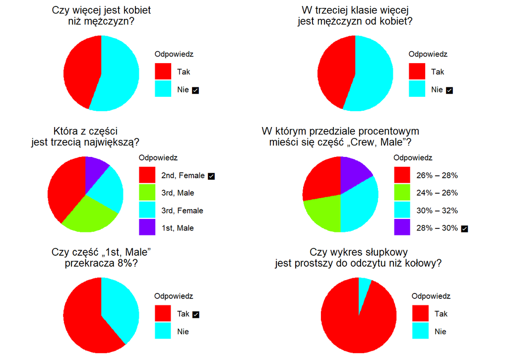

```r
tabelka_long <- tabelka[1:18,] %>%
 rename(id = Odpowiedzi) %>%
  pivot_longer(
    cols = starts_with("Pytanie"),
    names_to = "Pytanie",
    values_to = "Odpowiedz" )

pytania_tytuly <- c(
  "Czy więcej jest kobiet\nniż mężczyzn?",
  "W trzeciej klasie więcej\njest mężczyzn od kobiet?",
  "Która z części\njest trzecią największą?",
  "W którym przedziale procentowym\nmieści się część „Crew, Male”?",
  "Czy część „1st, Male”\nprzekracza 8%?",
  "Czy wykres słupkowy\njest prostszy do odczytu niż kołowy?"
)

poprawne_odp <- tabelka[19, paste0("Pytanie ", 1:5)] %>%
  unlist(use.names = FALSE) %>%
  as.character()

wykresy <- tabelka_long %>%
  group_by(Pytanie) %>%
  group_split() %>%
  lapply(function(df) {
  idx <- as.integer(sub("Pytanie", "", df$Pytanie[1]))
  odpetyk <- unique(df$Odpowiedz)

  # Ustal poziomy w tej samej kolejności
  df$Odpowiedz <- factor(df$Odpowiedz, levels = odpetyk)

  kolory <- rainbow(length(odpetyk))

  labels <- setNames(
    ifelse(
      idx <= 5 & odpetyk == poprawne_odp[idx],
      paste0(odpetyk, " ✅"),
      odpetyk
    ),
    odpetyk
  )

  ggplot(df, aes(x = "", fill = Odpowiedz)) +
    geom_bar(width = 1) +
    coord_polar(theta = "y") +
    scale_fill_manual(values = setNames(kolory, odpetyk),
                      labels = labels) +
    labs(title = pytania_tytuly[idx]) +
    theme_void() +
    theme(
      legend.position = "right",
      plot.title = element_text(size = 10, hjust = 0.5),
      legend.text = element_text(size = 8),
      legend.title = element_text(size = 8)
    )
})

gridExtra::grid.arrange(grobs = wykresy, ncol = 2)
```

# Podsumowanie (Wnioski)

Celem eksperymentu było sprawdzenie, czy powszechnie przyjęte zasady wizualizacji danych – takie jak unikanie wykresów kołowych, ograniczanie liczby używanych kolorów czy preferowanie wykresów słupkowych – znajdują potwierdzenie w rzeczywistym odbiorze społecznym. Wyniki badania pokazują, że większość uczestników wskazała wykres słupkowy jako bardziej czytelny i przystępny. Nie ma problemó z odczytaniem kątó, które jest dla nas uciążliwe. Również możemy zredukować liczbę koloró, co pomaga osobom z zaburzeniami widzenia kolorów. Należy również pamiętać, że wykresy odczytujemy całe życie i są pewne przyzwyczsajenia, które nie zawsze się pokrywają z tym co jest najlepsze dla innych osób oraz ze schematami opracowanymi przez naukowców.